# taxi

In a first step, visualize the relationship and subsequently test for a statistically significant link between the **overtreatment index** and *the alleged income*, *the alleged origin of the passenger*. What are your conclusions?

Moreover, investigate the relationship, both graphically and in terms of significance, between the occurrence of charging a too high price (overcharge) and income and origin of the passenger, respectively.

```python
import pandas as pd
import numpy as np
from matplotlib import pyplot as plt
import seaborn as sns
```

```python
taxi = pd.read_csv("Taxi.csv")
taxi.head()
```

|  | triple | origin | income | rushhour | dgender | dage | overtreatment | overcharge |
| --- | --- | --- | --- | --- | --- | --- | --- | --- |
| 0 | 1 | resident | high | yes | male | 45 | 1.109153 | no |
| 1 | 1 | nonresident | low | yes | male | 45 | 1.000000 | no |
| 2 | 1 | foreign | high | yes | male | 50 | 1.088383 | no |
| 3 | 2 | resident | high | no | male | 50 | 1.159961 | no |
| 4 | 2 | nonresident | low | no | male | 50 | 1.129784 | no |

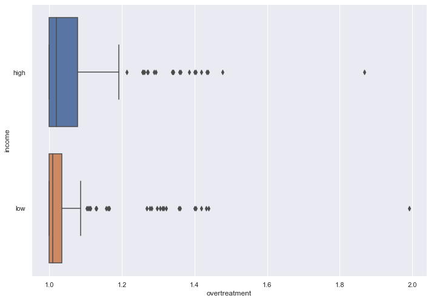

```python
#overtreatment and income
#overtreatment and origin

sns.set(rc={'figure.figsize':(11.7,8.27)})
sns.boxplot(x = "overtreatment", y = "income", data = taxi)
```

as we can see people with high income gets overtreatment more often than people with low income. but sometime person with low income can be overtreated even more than perso with high income. also we can see that it is not unusual to overtreat people with low income Conclusion: even if people would dress as they donthave money they still can and would be overtreated sometimes.

```python
from scipy.stats import iqr

# Compute summary statistics for each income (low and high)
tab = taxi.groupby("income")["overtreatment"].agg(n=len,
                                               mean=np.mean,
                                               median=np.median,
                                               sd=np.std,
                                               iqr=iqr,
                                               min=min,
                                               max=max)
print(tab)
```

```
            n      mean    median      sd       iqr  min       max
income
high    174.0  1.073239  1.019007  0.1262  0.077694  1.0  1.868810
low     174.0  1.055032  1.009017  0.1220  0.034792  1.0  1.991191
```

mean and median are quite similar, but iqr has a huge difference between high and low income, so for high income more data lay between Q1 and Q3 than for low income

```python
from scipy import stats
taxi['income'] = taxi['income'].map({'high': 1, 'low': 0})
r, p = stats.pearsonr(x=taxi["income"], y=taxi["overtreatment"])
print(r)
```

```
0.07336049859146661
```

correlation between income and overtreatment is not so big so we can make a conclusion that the way person look do not affect if they would be overtreated or not

```python
from statsmodels.stats.oneway import anova_oneway

res = anova_oneway(data=taxi["overtreatment"], groups=taxi["income"], use_var='equal', welch_correction=False)
print(res)
```

```
statistic = 1.8721654630995062
pvalue = 0.17211511538435328
df = (1.0, 346.0)
df_num = 1.0
df_denom = 346.0
nobs_t = 348.0
n_groups = 2
means = [1.05503213 1.07323946]
nobs = [174. 174.]
vars_ = [0.01488402 0.0159264 ]
use_var = equal
welch_correction = False
tuple = (1.8721654630995062, 0.17211511538435328)
```

statistic : more variance explained than not explained

pvalue : since this probability is large (p-value > 0.05), we conclude that the null hypothesis is true. Null hypothesis is a typical statistical theory which suggests that no statistical relationship and significance exists in a set of given single observed variable, between two sets of observed data and measured phenomena.

nobs : number of observation for each values

means : means values of high and low income

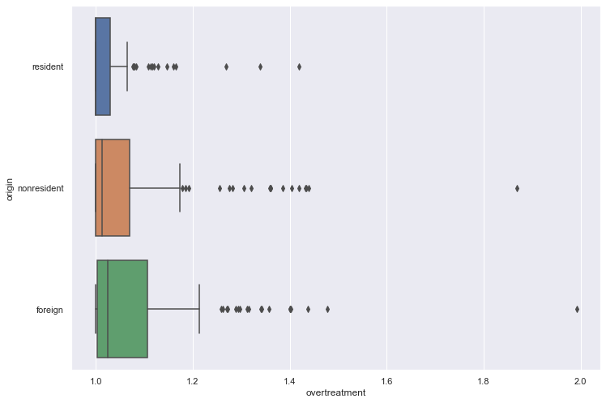

```python
sns.boxplot(x = "overtreatment", y = "origin", data = taxi)
```

```python
tab = taxi.groupby("origin")["overtreatment"].agg(n=len,
                                               mean=np.mean,
                                               median=np.median,
                                               sd=np.std,
                                               iqr=iqr,
                                               min=min,
                                               max=max)
print(tab)
```

```
                 n      mean    median        sd       iqr  min       max
origin
foreign      116.0  1.087244  1.025519  0.145393  0.101909  1.0  1.991191
nonresident  116.0  1.076503  1.013167  0.139444  0.070238  1.0  1.868810
resident     116.0  1.028660  1.000088  0.063673  0.030061  1.0  1.418649
```

```python
taxi['origin'] = taxi['origin'].map({'foreign': 2, 'nonresident': 1, 'resident': 0})
r, p = stats.pearsonr(x=taxi["origin"], y=taxi["overtreatment"])
print(r)
```

```
0.19273062818337966
```

correlation is a relationship between two variables in which one variable increases as the other also increases. so the overtreatment will be rising from resident (0) to foreign (2)

```python
res = anova_oneway(data=taxi["overtreatment"], groups=taxi["origin"], use_var='equal', welch_correction=False)
print(res)
```

```
statistic = 7.583565437072355
pvalue = 0.0005981922021570122
df = (2.0, 345.0)
df_num = 2.0
df_denom = 345.0
nobs_t = 348.0
n_groups = 3
means = [1.02865991 1.07650336 1.0872441 ]
nobs = [116. 116. 116.]
vars_ = [0.00405429 0.01944454 0.02113915]
use_var = equal
welch_correction = False
tuple = (7.583565437072355, 0.0005981922021570122)
```

statistic : more variance explained than not explained

pvalue : since this probability is small (p-value < 0.05), we conclude that the null hypothesis is not true. We can conclude that statistical relationship and significance exists in a set of given single observed variable, between two sets of observed data and measured phenomena.

nobs : number of observation for each values

```python
# Contingency table
tabio = pd.crosstab(taxi['income'], taxi['overcharge'])
print(tabio)
```

```
overcharge   no  yes
income
0           155   19
1           154   20
```

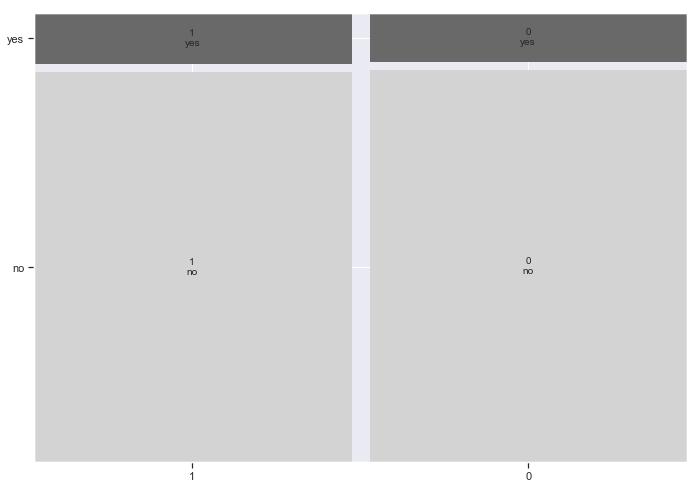

```python
from statsmodels.graphics.mosaicplot import mosaic
grey_scale = lambda key: {'color': 'dimgrey' if 'yes' in key else 'lightgrey'} # Define a colo
mosaic(taxi, ["income", "overcharge"], properties=grey_scale, gap=0.03);
```

as we can see for people with high income and low income overcharge situation is similar, so the way person look doesnot affect if he would be overcharge or not

```python
from scipy.stats import chi2_contingency
chi2, p, dof, ex = chi2_contingency(tabio, correction=False)

print("X-squared = {:.3f}, df = {:.3f}, p-value = {:.3g}".format(chi2, dof, p))
```

```
X-squared = 0.029, df = 1.000, p-value = 0.865
```

X-squared is smaller than the chi-square critical value, so we "fail to reject" the null hypothesis. This two variables are independent.

```python
taxi['overcharge'] = taxi['overcharge'].map({'no': 0, 'yes': 1})
r, p = stats.pearsonr(x=taxi["income"], y=taxi["overcharge"])
print(r)
```

```
0.00910937239906994
```

indeed, this two variables are independent

```python
taboo = pd.crosstab(taxi['origin'], taxi['overcharge'])
print(taboo)
```

```
overcharge    0   1
origin
0           112   4
1           107   9
2            90  26
```

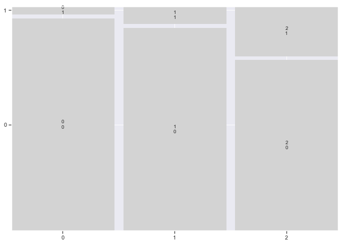

```python
# overcharge: 'yes' 1, 'no' 0
# origin: 'resident' 0, 'nonresident' 1, 'foreign' 2
mosaic(data=taxi, index=['origin', 'overcharge'], properties=grey_scale, gap=0.03, statistic=True);
plt.show()
```

foreign people get overcharge more often than residents.

```python
chi2, p, dof, ex = chi2_contingency(taboo, correction=False)

print("X-squared = {:.3f}, df = {:.3f}, p-value = {:.3g}".format(chi2, dof, p))
```

```
X-squared = 23.044, df = 2.000, p-value = 9.91e-06
```

X-squared is greater than the chi-square critical value, so we reject the null hypothesis that variables are independent and say that variables are not independent.

```python
r, p = stats.pearsonr(x=taxi["origin"], y=taxi["overcharge"])
print(r)
```

```
0.24544645680185428
```

indeed, correlation shows as that variable 'origin' and 'overcharge' are not independent